# IODS course project

Lauri-Pekka Aho

# About the project

Hello world!  
[Link to GitHub](https://github.com/lauripah/IODS-project)

# Chapter 2

*Regression and model validation*

Students2014 data (or learning2014 in my case) has 166 observations of 7 variables. The variables are gender, age, attitude (shows persons attitude towards statistics), deep (deep learning), stra (strategic questions), surf (surface learning) and points from exam.

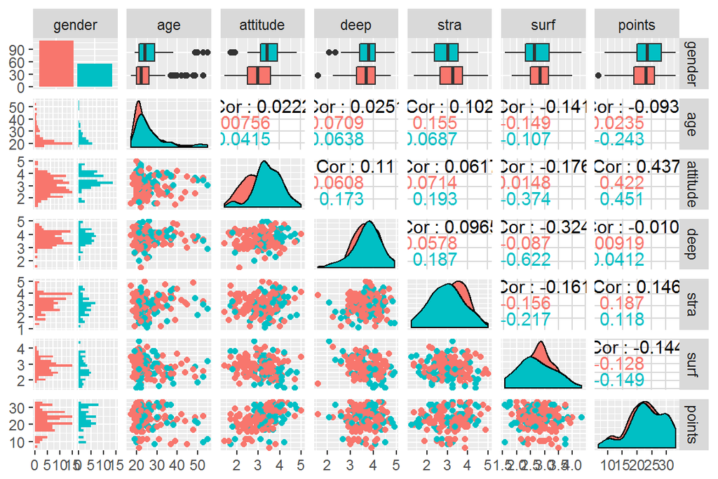

```r
setwd("~/IODS/IODS-project/data")
learning2014<-read.table("learning2014.txt")

library(ggplot2)
library(GGally)

p <- ggpairs(learning2014, mapping = aes(col = gender), lower = list(combo = wrap("facethist", bins = 20)))
p
```

Matrix above is called scatter matrix. For example it shows correlation and scatterplots between all variables.

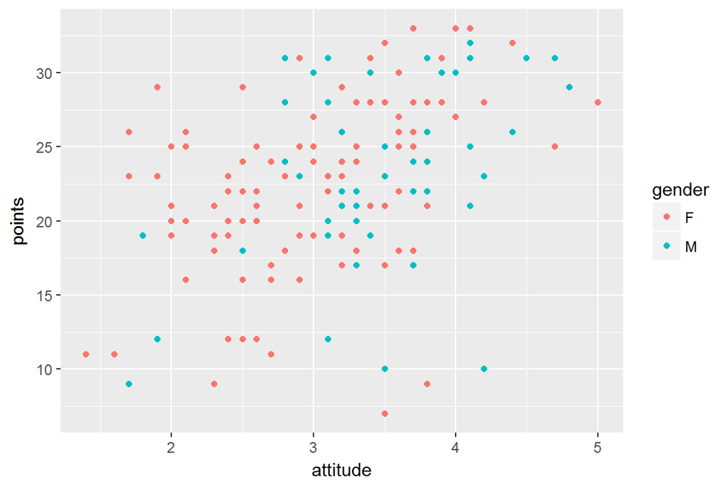

```r
setwd("~/IODS/IODS-project/data")
learning2014<-read.table("learning2014.txt")

library(ggplot2)

p1 <- ggplot(learning2014, aes(x = attitude, y = points, col=gender))
p2 <- p1 + geom_point()
p3 <- p2 + geom_smooth(method = "lm")
p4 <- ggtitle("Student's attitude versus exam points")
p2
```

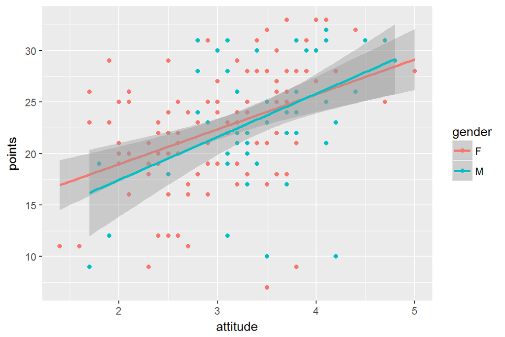

```r
p3
```

The plot above shows attitude versus points in exam with regression lines separated by gender.

```r
my_model2 <- lm(points ~ attitude, data = learning2014)
summary(my_model2)
```

```
##
## Call:
## lm(formula = points ~ attitude, data = learning2014)
##
## Residuals:
##      Min       1Q   Median       3Q      Max
## -16.9763  -3.2119   0.4339   4.1534  10.6645
##
## Coefficients:
##             Estimate Std. Error t value Pr(>|t|)
## (Intercept)  11.6372     1.8303   6.358 1.95e-09 ***
## attitude      3.5255     0.5674   6.214 4.12e-09 ***
## ---
## Signif. codes:  0 '***' 0.001 '**' 0.01 '*' 0.05 '.' 0.1 ' ' 1
##
## Residual standard error: 5.32 on 164 degrees of freedom
## Multiple R-squared:  0.1906, Adjusted R-squared:  0.1856
## F-statistic: 38.61 on 1 and 164 DF,  p-value: 4.119e-09
```

The summary above shows summary of a regression model in which the dependent variable is exam points and the explanatory variable is attitude. I also tried using deep and surf as explanatory variables but they were not statistifically significant because the gotten p-value was > 0.05. It seems that attitude towards statistics has affects the amount of points in exam. Summary shows R-squared value of 0.1906. This value shows linear relation between attitude and points. Because of such low value, the linear relation between variables is fairly low.

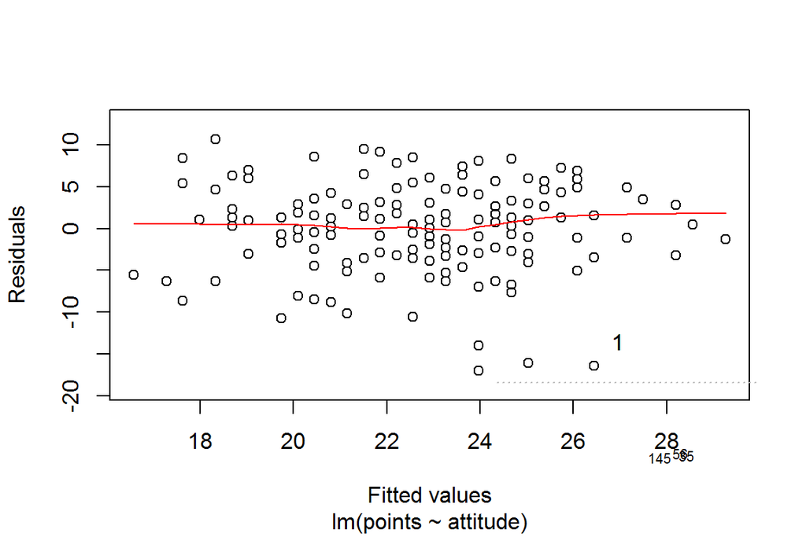

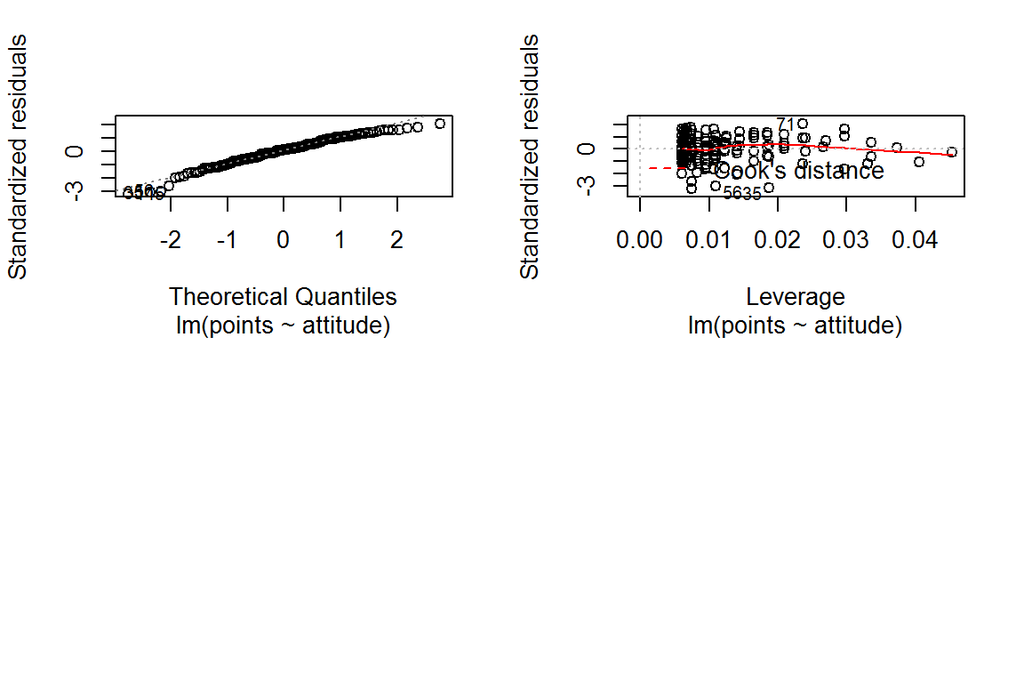

```r
plot(my_model2,which=c(1,2,5),par(mfrow = c(2,2)))
```

The first plot shows where the residuals are compared to fitted values of points ~ attitude. Second plot shows normal QQ-plot which standardizes the values to a standard normal distribution N~(0,1). The new residuals follow the fit line very well. The third plot shows how much leverage a single residual has over the fit line. The highest value of leverage of a single residual is only about 0.04 which is very low. All in all it seems to be a good model.

# Chapter 3

*Logistic regression*

First I read the data (alc.csv) created in data wrangling exercise.

```r
setwd("~/IODS/IODS-project/data")
alc <- read.csv("alc.csv", sep = ",")
alc <- alc[,2:36]
colnames(alc)
```

```
##  [1] "school"     "sex"        "age"        "address"    "famsize"
##  [6] "Pstatus"    "Medu"       "Fedu"       "Mjob"       "Fjob"
## [11] "reason"     "nursery"    "internet"   "guardian"   "traveltime"
## [16] "studytime"  "failures"   "schoolsup"  "famsup"     "paid"
## [21] "activities" "higher"     "romantic"   "famrel"     "freetime"
## [26] "goout"      "Dalc"       "Walc"       "health"     "absences"
## [31] "G1"         "G2"         "G3"         "alc_use"    "high_use"
```

Code above prints out names of the columns in the alc-data. There are some background questions such as school, sex and age, some questions about school such as studytime and whether the person has taken extra paid classes and the focus of this data, the use of alcohol and health status.

My four interesting variables to study are studytime, failures, absences and nursery. Studytime shows weekly study time in which value 1 is less than 2 hours, 2 is 2 to 5 hours, 3 is 5 to 10 hours and 4 is more than 10 hours. I think this has a effect on use of alcohol because when you are studying you don’t have time to use alcohol. Failures show how many times has a person failed to pass a test. Failure tells how many times a person has failed the class. This variable is coded in a numeric way; 1,2,3 or 4 or more times. Maybe a 4 in this means higher use of alcohol. Absences are number of school absences which probably also correlates to alcohol use. Nursery variable tells if a person attended nursery school. False could lead to higher use of alcohol.

```r
m <- glm(high_use ~ failures + absences + nursery + studytime, data = alc, family = "binomial")
m
```

```
##
## Call:  glm(formula = high_use ~ failures + absences + nursery + studytime,
##     family = "binomial", data = alc)
##
## Coefficients:
## (Intercept)     failures     absences   nurseryyes    studytime
##    -0.14643      0.36253      0.08071     -0.31588     -0.47283
##
## Degrees of Freedom: 381 Total (i.e. Null);  377 Residual
## Null Deviance:       465.7
## Residual Deviance: 428.8     AIC: 438.8
```

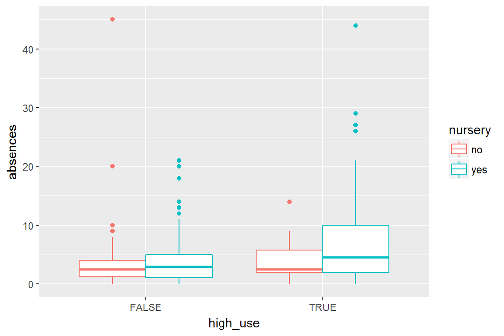

```r
library(ggplot2)
g1 <- ggplot(alc, aes(x = high_use, y = absences, col = nursery))
g1 + geom_boxplot() + ylab("absences")
```

Plot above shows high usage of alcohol on X-axis and absences on Y-axis with nursery being the color. It seems that people who attended nursery school actually have more absences.

# Chapter 4

*Clustering and classification*

First I loaded the Boston data from MASS package.

```r
library(MASS)
data("Boston")
dim(Boston)
```

```
## [1] 506  14
```

You can see that the Boston-data is a dataset in which there are 506 observations of 14 variables. The Boston-data is about housing values in suburbs of Boston.

```r
str(Boston)
```

```
## 'data.frame':    506 obs. of  14 variables:
##  $ crim   : num  0.00632 0.02731 0.02729 0.03237 0.06905 ...
##  $ zn     : num  18 0 0 0 0 0 12.5 12.5 12.5 12.5 ...
##  $ indus  : num  2.31 7.07 7.07 2.18 2.18 2.18 7.87 7.87 7.87 7.87 ...
##  $ chas   : int  0 0 0 0 0 0 0 0 0 0 ...
##  $ nox    : num  0.538 0.469 0.469 0.458 0.458 0.458 0.524 0.524 0.524 0.524 ...
##  $ rm     : num  6.58 6.42 7.18 7 7.15 ...
##  $ age    : num  65.2 78.9 61.1 45.8 54.2 58.7 66.6 96.1 100 85.9 ...
##  $ dis    : num  4.09 4.97 4.97 6.06 6.06 ...
##  $ rad    : int  1 2 2 3 3 3 5 5 5 5 ...
##  $ tax    : num  296 242 242 222 222 222 311 311 311 311 ...
##  $ ptratio: num  15.3 17.8 17.8 18.7 18.7 18.7 15.2 15.2 15.2 15.2 ...
##  $ black  : num  397 397 393 395 397 ...
##  $ lstat  : num  4.98 9.14 4.03 2.94 5.33 ...
##  $ medv   : num  24 21.6 34.7 33.4 36.2 28.7 22.9 27.1 16.5 18.9 ...
```

The variables vary from crime rate per capita to whether the suburb bounds river Charles.

```r
summary(Boston)
```

```
##       crim                zn             indus            chas
##  Min.   : 0.00632   Min.   :  0.00   Min.   : 0.46   Min.   :0.00000
##  1st Qu.: 0.08204   1st Qu.:  0.00   1st Qu.: 5.19   1st Qu.:0.00000
##  Median : 0.25651   Median :  0.00   Median : 9.69   Median :0.00000
##  Mean   : 3.61352   Mean   : 11.36   Mean   :11.14   Mean   :0.06917
##  3rd Qu.: 3.67708   3rd Qu.: 12.50   3rd Qu.:18.10   3rd Qu.:0.00000
##  Max.   :88.97620   Max.   :100.00   Max.   :27.74   Max.   :1.00000
##       nox               rm             age              dis
##  Min.   :0.3850   Min.   :3.561   Min.   :  2.90   Min.   : 1.130
##  1st Qu.:0.4490   1st Qu.:5.886   1st Qu.: 45.02   1st Qu.: 2.100
##  Median :0.5380   Median :6.208   Median : 77.50   Median : 3.207
##  Mean   :0.5547   Mean   :6.285   Mean   : 68.57   Mean   : 3.795
##  3rd Qu.:0.6240   3rd Qu.:6.623   3rd Qu.: 94.08   3rd Qu.: 5.188
##  Max.   :0.8710   Max.   :8.780   Max.   :100.00   Max.   :12.127
##       rad              tax           ptratio          black
##  Min.   : 1.000   Min.   :187.0   Min.   :12.60   Min.   :  0.32
##  1st Qu.: 4.000   1st Qu.:279.0   1st Qu.:17.40   1st Qu.:375.38
##  Median : 5.000   Median :330.0   Median :19.05   Median :391.44
##  Mean   : 9.549   Mean   :408.2   Mean   :18.46   Mean   :356.67
##  3rd Qu.:24.000   3rd Qu.:666.0   3rd Qu.:20.20   3rd Qu.:396.23
##  Max.   :24.000   Max.   :711.0   Max.   :22.00   Max.   :396.90
##      lstat            medv
##  Min.   : 1.73   Min.   : 5.00
##  1st Qu.: 6.95   1st Qu.:17.02
##  Median :11.36   Median :21.20
##  Mean   :12.65   Mean   :22.53
##  3rd Qu.:16.95   3rd Qu.:25.00
##  Max.   :37.97   Max.   :50.00
```

Summary of the data.

```r
boston_scaled <- scale(Boston)
boston_scaled <- as.data.frame(boston_scaled)
summary(boston_scaled)
```

```
##       crim                 zn               indus
##  Min.   :-0.419367   Min.   :-0.48724   Min.   :-1.5563
##  1st Qu.:-0.410563   1st Qu.:-0.48724   1st Qu.:-0.8668
##  Median :-0.390280   Median :-0.48724   Median :-0.2109
##  Mean   : 0.000000   Mean   : 0.00000   Mean   : 0.0000
##  3rd Qu.: 0.007389   3rd Qu.: 0.04872   3rd Qu.: 1.0150
##  Max.   : 9.924110   Max.   : 3.80047   Max.   : 2.4202
##       chas              nox                rm               age
##  Min.   :-0.2723   Min.   :-1.4644   Min.   :-3.8764   Min.   :-2.3331
##  1st Qu.:-0.2723   1st Qu.:-0.9121   1st Qu.:-0.5681   1st Qu.:-0.8366
##  Median :-0.2723   Median :-0.1441   Median :-0.1084   Median : 0.3171
##  Mean   : 0.0000   Mean   : 0.0000   Mean   : 0.0000   Mean   : 0.0000
##  3rd Qu.:-0.2723   3rd Qu.: 0.5981   3rd Qu.: 0.4823   3rd Qu.: 0.9059
##  Max.   : 3.6648   Max.   : 2.7296   Max.   : 3.5515   Max.   : 1.1164
##       dis               rad               tax             ptratio
##  Min.   :-1.2658   Min.   :-0.9819   Min.   :-1.3127   Min.   :-2.7047
##  1st Qu.:-0.8049   1st Qu.:-0.6373   1st Qu.:-0.7668   1st Qu.:-0.4876
##  Median :-0.2790   Median :-0.5225   Median :-0.4642   Median : 0.2746
##  Mean   : 0.0000   Mean   : 0.0000   Mean   : 0.0000   Mean   : 0.0000
##  3rd Qu.: 0.6617   3rd Qu.: 1.6596   3rd Qu.: 1.5294   3rd Qu.: 0.8058
##  Max.   : 3.9566   Max.   : 1.6596   Max.   : 1.7964   Max.   : 1.6372
##      black             lstat              medv
##  Min.   :-3.9033   Min.   :-1.5296   Min.   :-1.9063
##  1st Qu.: 0.2049   1st Qu.:-0.7986   1st Qu.:-0.5989
##  Median : 0.3808   Median :-0.1811   Median :-0.1449
##  Mean   : 0.0000   Mean   : 0.0000   Mean   : 0.0000
##  3rd Qu.: 0.4332   3rd Qu.: 0.6024   3rd Qu.: 0.2683
##  Max.   : 0.4406   Max.   : 3.5453   Max.   : 2.9865
```

Using the scale() -function I standardized the data. Now every single variable has mean of 0.

```r
scaled_crim <- boston_scaled$crim
bins <- quantile(scaled_crim)
crime <- cut(scaled_crim, breaks = bins, include.lowest = TRUE)
boston_scaled <- dplyr::select(boston_scaled, -crim)
boston_scaled <- data.frame(boston_scaled, crime)
n <- nrow(boston_scaled)
ind <- sample(n,  size = n * 0.8)
train <- boston_scaled[ind,]
test <- boston_scaled[-ind,]
```

Code above creates the train and test datas.

```r
lda.fit <- lda(crime ~ . , data = train)
lda.fit
```

```
## Call:
## lda(crime ~ ., data = train)
##
## Prior probabilities of groups:
## [-0.419,-0.411]  (-0.411,-0.39] (-0.39,0.00739]  (0.00739,9.92]
##       0.2623762       0.2400990       0.2425743       0.2549505
##
## Group means:
##                          zn      indus        chas        nox          rm
## [-0.419,-0.411]  0.98089724 -0.9154303 -0.12375925 -0.8829884  0.45992136
## (-0.411,-0.39]  -0.07990739 -0.3387724 -0.02879709 -0.5425665 -0.09832950
## (-0.39,0.00739] -0.38135991  0.1441374  0.20976484  0.3342621  0.04917228
## (0.00739,9.92]  -0.48724019  1.0149946 -0.11943197  1.0433172 -0.44505368
##                        age        dis        rad        tax     ptratio
## [-0.419,-0.411] -0.8571812  0.8981306 -0.6925875 -0.7512560 -0.51370224
## (-0.411,-0.39]  -0.3305934  0.3325237 -0.5390602 -0.4409689 -0.06898466
## (-0.39,0.00739]  0.4022563 -0.3684674 -0.3783401 -0.3057064 -0.23586535
## (0.00739,9.92]   0.8149755 -0.8652580  1.6596029  1.5294129  0.80577843
##                       black       lstat        medv
## [-0.419,-0.411]  0.37458684 -0.77346292  0.54315962
## (-0.411,-0.39]   0.32901196 -0.14314938  0.01784267
## (-0.39,0.00739]  0.07706749  0.03555151  0.11969715
## (0.00739,9.92]  -0.90591185  0.89661208 -0.72097309
##
## Coefficients of linear discriminants:
##                 LD1         LD2          LD3
## zn       0.13897340  0.72843691 -0.997974978
## indus   -0.01912336 -0.25829288 -0.079373688
## chas    -0.09387498 -0.10802284  0.032328909
## nox      0.31817218 -0.66619801 -1.292183059
## rm      -0.12271951 -0.06357295 -0.121859601
## age      0.33800470 -0.24607861 -0.331552876
## dis     -0.07550549 -0.14754434  0.006990154
## rad      3.24873661  0.94649538 -0.474994483
## tax     -0.04554374 -0.02685140  1.190425933
## ptratio  0.11989764  0.07893794 -0.229200262
## black   -0.17585422 -0.01500957  0.143159047
## lstat    0.17647156 -0.25399348  0.333016097
## medv     0.12005893 -0.33299780 -0.226977452
##
## Proportion of trace:
##    LD1    LD2    LD3
## 0.9540 0.0349 0.0112
```

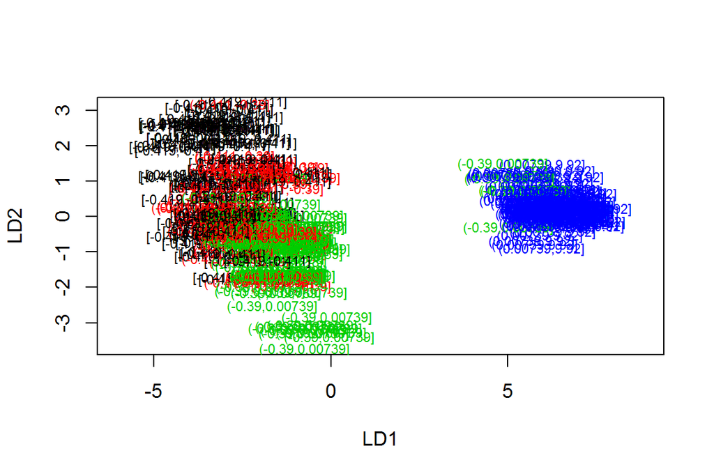

```r
classes <- as.numeric(train$crime)
plot(lda.fit, dimen = 2,col = classes, pch = classes)
```

This is the linear discriminant analysis biplot.

```r
correct_classes <- test$crime
test <- dplyr::select(test, -crime)
lda.pred <- predict(lda.fit, newdata = test)
table(correct = correct_classes, predicted = lda.pred$class)
```

```
##                  predicted
## correct           [-0.419,-0.411] (-0.411,-0.39] (-0.39,0.00739]
##   [-0.419,-0.411]               9             11               1
##   (-0.411,-0.39]                5             19               5
##   (-0.39,0.00739]               1              7              20
##   (0.00739,9.92]                0              0               1
##                  predicted
## correct           (0.00739,9.92]
##   [-0.419,-0.411]              0
##   (-0.411,-0.39]               0
##   (-0.39,0.00739]              0
##   (0.00739,9.92]              23
```

# Chapter 5

*Dimensionality reduction techniques*

```r
setwd("~/IODS/IODS-project/data")

human <- read.csv("human.csv", stringsAsFactors = F, sep=",", row.names = 1)

library(ggplot2)
library(dplyr)
library(stringr)
library(GGally)
```

First I loaded the data and necessary packages.

```r
str(human)
```

```
## 'data.frame':    155 obs. of  8 variables:
##  $ Edu2.FM  : num  1.007 0.997 0.983 0.989 0.969 ...
##  $ Labo.FM  : num  0.891 0.819 0.825 0.884 0.829 ...
##  $ Life.Exp : num  81.6 82.4 83 80.2 81.6 80.9 80.9 79.1 82 81.8 ...
##  $ Edu.Exp  : num  17.5 20.2 15.8 18.7 17.9 16.5 18.6 16.5 15.9 19.2 ...
##  $ GNI      : int  64992 42261 56431 44025 45435 43919 39568 52947 42155 32689 ...
##  $ Mat.Mor  : int  4 6 6 5 6 7 9 28 11 8 ...
##  $ Ado.Birth: num  7.8 12.1 1.9 5.1 6.2 3.8 8.2 31 14.5 25.3 ...
##  $ Parli.F  : num  39.6 30.5 28.5 38 36.9 36.9 19.9 19.4 28.2 31.4 ...
```

```r
dim(human)
```

```
## [1] 155   8
```

Above you can see the structure and dimensions of the human.csv data. This data has 155 observations of 8 variables. Its variables describe human values such as life expectancy and expected length of education.

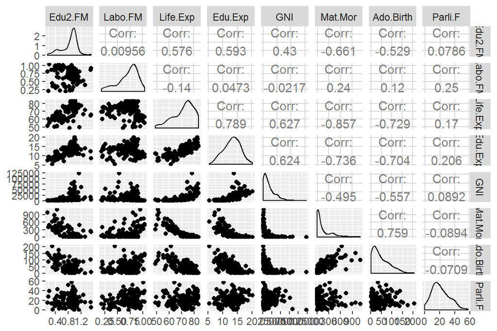

```r
ggpairs(human)
```

Above you can see visualization of the data. The variables have surprisingly large correlation values between variables. For example -0.857 correlation between maternal mortality and life expectancy. Expected lenght of education seems to be quite normally distributed.

```r
pca_human <- prcomp(human)
summary(pca_human)
```

```
## Importance of components:
##                              PC1      PC2   PC3   PC4   PC5   PC6    PC7
## Standard deviation     1.854e+04 185.5219 25.19 11.45 3.766 1.566 0.1912
## Proportion of Variance 9.999e-01   0.0001  0.00  0.00 0.000 0.000 0.0000
## Cumulative Proportion  9.999e-01   1.0000  1.00  1.00 1.000 1.000 1.0000
##                           PC8
## Standard deviation     0.1591
## Proportion of Variance 0.0000
## Cumulative Proportion  1.0000
```

Above you can see the summary of the principal components.

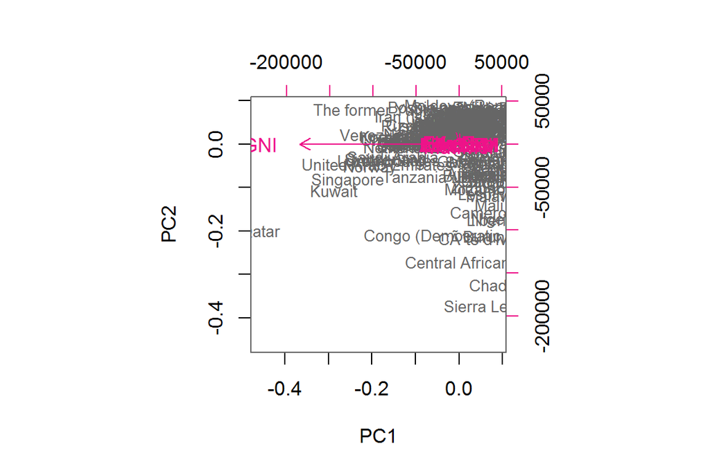

```r
biplot(pca_human, choices = 1:2, cex = c(0.8, 1), col = c("grey40", "deeppink2"))
```

You really can’t tell much of the non-standardized biplot. Its a mess. Now let’s standardize the data and plot it.

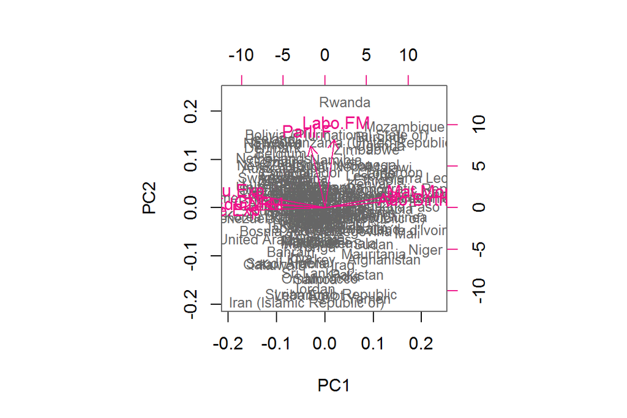

```r
human_std <- scale(human)
pca_human <- prcomp(human_std)
biplot(pca_human, choices = 1:2, cex = c(0.8, 1), col = c("grey40", "deeppink2"))
```

As you can see the distribution is now distributed more all-around. This is because the data has been changed to a standard normal distribution.